# 52414: Home Exam 204590780

July 18th, 2021

### Q0.Submission Instructions (Please read carefully)

The exam will be submitted **individually** by uploading the solved exam `Rmd` and `html` files to the course `moodle`. Please name your files as `52414-HomeExam_ID.Rmd` and `52414-HomeExam_ID.html` where `ID` is replaced by your ID number (do **not** write your name in the file name or in the exam itself). The number of points for each sub-question is indicated next to it, with $105$ points overall. The total grade will be at most $100$.

Once you click on the `moodle` link for the home exam, the exam will start and you have three days (72 hours) to complete and submit it. The exam will be available from July 18th to July 30th. The last submission time is June 30th at 23:59.  
You may use all course materials, the web and other written materials and R libraries. You are NOT allowed to discuss any of the exam questions/materials with other students.

**Analysis and Presentation of Results:**

Write your answers and explanations in the text of the `Rmd` file (*not* in the `code`).  
The text of your answers should be next to the relevant code, plots and tables and refer to them, and not at a separate place at the end.  
You need to explain every step of your analysis. When in doubt, a more detailed explanation is better than omitting explanations.

Give informative titles, axis names and names for each curve/bar in your graphs. In some graphs you may need to change the graph limits. If you do so, please include the outlier points you have removed in a separate table.  
Add informative comments explaining your code

Whenever possible, use *objective* and *specific* terms and quantities learned in class, and avoid *subjective* and *general* unquantified statements. For example:  
`Good:` “We see a $2.5$-fold increase in the curve from Jan. 1st to March 1st”.  
`Bad:` “The curve goes up at the beginning”.  
`Good:` “The median is $4.7$. We detected five outliers with distance $>3$ standard deviations from the median”.  
`Bad:` “The five points on the sides seem far from the middle”.

Sometimes `Tables` are the best way to present your results (e.g. when asked for a list of items). Exclude irrelevant rows/columns. Display clearly items’ names in your `Tables`.

Show numbers in plots/tables using standard digits and not scientific display. That is: 90000000 and not 9e+06.  
Round numbers to at most 3 digits after the dot - that is, 9.456 and not 9.45581451044

Some questions may require data wrangling and manipulation which you need to decide on. The instructions may not specify precisely the exact plot you should use (for example: `show the distribution of ...`). In such cases, you should decide what and how to show the results.

When analyzing real data, use your best judgment if you encounter missing values, negative values, NaNs, errors in the data etc. (e.g. excluding them, zeroing negative values..) and mention what you have done in your analysis in such cases.

Required libraries are called in the `Rmd` file. Install any library missing from your `R` environment. You are allowed to add additional libraries if you want. If you do so, *please add them at the start of the Rmd file, right below the existing libraries, and explain what libraries you’ve added, and what is each new library used for*.

## Q1. Two Armies Simulation (45 pt)

[figure not shown]

Consider two armies of $10$ `R` loving statisticians and $10$ `Python` loving statisticians, facing each other in a shootout, fighting to the death over which language is better.

Once the battle starts, assume that each statistician tries to shoot as fast as she can, where the time until shooting has an exponential distribution with $\lambda=1$. After a shot is fired, the statistician keeps firing, with the time to the next shot again distributed as $exp(1)$. Each statistician keeps shooting until she is shot and killed herself by a statistician from the opposing army, and leaves the battle. The times until shooting the next bullet for all statisticians and all shots are independent.  
At each shot, the statistician chooses as target **uniformly at random** a member from the remaining **living members** of the opposing army.  
The battle keeps going until all persons from one of the armies die, and then the other army is declared the `winner`. Let $X$ be the number of remaining statisticians from the `winner` army when the battle ends.  
Throughout this question, assume that statisticians are **perfect shooters**, and always hit their target (the choice of the target changes however between different sub-questions below).

1. (5pt) Describe `in words only` (no code) a simulation strategy to estimate $E[X]$ and $Var(X)$, including how would you simulate a battle between the two armies.  
   **Hint:** remember that the exponential distribution has a memoryless property: $Pr(T>t) = Pr(T > t+s | T>s)$, $\forall t, s > 0$.  
   You can perform the simulations in this question exactly as described, which may take many minutes to run, or perform **simpler** and **faster** simulations using probabilistic arguments, provided that they are **equivalent** to the description in the question.  
   (For example, if you were requested to simulate $n$ i.i.d. $Bernouli(p)$ random variables and report their sum, you could argue that instead it is enough to simulate a single $Bionomial(n,p)$ random variable).
2. (8pt) Simulate $1,000$ random battles as described in the question and use them to estimate $E[X]$ and $Var(X)$ from the random simulations.  
   It is recommended to write a function for the simulation and call it, such that the simulation function can be used also in the subsequent sub-questions.
3. (8pt) Now, change $n$, the number of statisticians in each army, to be $n=10, 20, 40, ..., 10240$ (each time multiplying $n$ by two), and let $X_n$ be the random variable counting the number of remaining winners when starting with $n$ statisticians in each army. (so the variable $X$ from (a.) corresponds to $X_{10}$).  
   For each value of $n$ simulate $100$ random battles and estimate $\mu_n \equiv E[X_n]$. Plot your estimate vs. $n$.  
   Find a simple function $f(n)$ such that it holds that $\mu_n \approx f(n)$ based on the plot. (**Hint:** you can use log-scale).
4. (8pt) In this sub-question, assume that all statisticians in both armies have used their programming language too much so they became to hate it, and therefore in each shot they aim and kill a random member from their **own** army (including possibly themselves).  
   Modify the simulation to accommodate this case, and repeat the simulation, plot and finding a function $f(n)$ as in (c.) for this case.  
   Explain in words the differences in results between the two cases.
5. (8pt) In this sub-question, assume that all statisticians in both armies are **completely drunk**, and shoot randomly one of the **remaining persons alive** (from both armies) including themselves (they still always hit their target).  
   Repeat all the steps of (c.) for this case (as you did in (d.)). Are the results similar or different? why?
6. (8pt) Finally, suppose in this sub-question that statisticians that are shot become zombies instead of being killed, and can still keep shooting at statisticians from the opposing army (as in (a.), (b.)).  
   All statisticians aim at and hit a random **living** (non-zombie) member from the opposing army. The battle ends when all members of a certain army become zombies, and then $X_n$ records the number of remaining living (non-zombie) statisticians in the other army.  
   Repeat the simulation, plot and finding a function $f(n)$ as in (c.) for this case.  
   Explain in words the differences in results between the this and the previous cases.

**Solutions:**

1. Just as in the Monte Carlo method - we can use random sampling in order to predict certain results. We can compute the expected value and variance by creating a simulation using many randomized repetitions, that way we would get closer to the original distribution. For the simulation we will go through the following stages:
- First we will the 2 teams and randomly assign the time for shooting for each player according to the given distribution - exponential(1). The decision which shooter shoots first will be determined upon the array of each team.
- The team which shoots first will be determined by the minimum shooting time possible between the teams.
- As the next shooting team will be selected we will also randomize kill one of the members on the opposing team using the uniform distribution. After each shooting the shooter will have to reload, once again this will be represented by a distribution of exp(1).
- We shall repeat this process until we will only have one team left. Each repetition counts as one simulation, for us to get a good estimation of the desired expected value and of variance we willl have to run the simulation many more times.
- Finally we need to calculate the expected value and the variance according to the results we’ll get from simulating.

```r
#Creating the function for the simulation
simulation <- function(sizeA,sizeB){

  #Divide the teams of statisticians, sort each team
  Rgroup <- rexp(sizeA, 1)
  Rgroup <- sort(Rgroup)
  PYgroup <- rexp(sizeB, 1)
  PYgroup <- sort(PYgroup)

  #Draw simulations
  while(length(Rgroup)>0 & length(PYgroup)>0){
    #As mentioned, the turns are determined according to which group has the shortest time until shooting
    if (Rgroup[1]<PYgroup[1]) {
      #Rgroup shoots
      kill_py <- rdunif(1,1,length(PYgroup))
      PYgroup <- PYgroup[-kill_py]
      Rgroup[1] <- Rgroup[1] + rexp(1,1) #Add the reload time to the shooting time of the player who took the shot
      Rgroup <- sort(Rgroup) #Resort the group according to the shooting time of each player
    }
    else {

      #PYgroup shoots, then comments are the same as for Rgroup
      kill_R <- rdunif(1,1,length(Rgroup))
      Rgroup <- Rgroup[-kill_R]
      PYgroup[1] <- PYgroup[1] + rexp(1,1)
      PYgroup <- sort(PYgroup)
    }
  }

  #Finish and save the data from the simulation
  survived <- length(Rgroup) + length(PYgroup)
}
```

```r
sim <- c()
#Simulate 1000 times
for(i in 1:1000){
  sim <- c(sim, simulation(10,10))
}


expectedValue <- mean(sim)
varValue <- var(sim)
```

```r
expectedValue
```

```
## [1] 5.806
```

```r
varValue
```

```
## [1] 4.909273
```

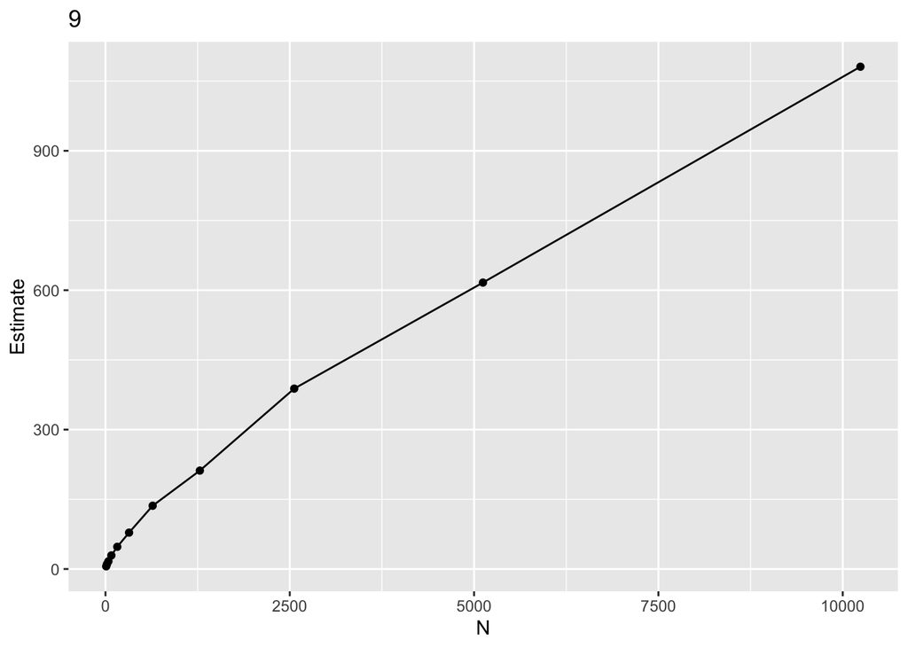

```r
n <- c(10,20,40,80,160,320,640,1280,2560,5120,10240)

#Create a dataframe to save the results
simData <- data.frame(N=NA, E=NA)
for (i in n){
  survivors <- c()

  for (j in 1:100){
  survivors <- c(survivors,simulation(i,i))
  }

  e_x <- mean(survivors)

  simData <- rbind(simData, c(i, e_x))
}

simData <- na.omit(simData)
colnames(simData) <- c("N", "Estimate")

graph <- ggplot(data=simData, aes(N, Estimate)) + geom_point()+geom_line()+ ggtitle(sim)
graph
```

```r
simData
```

```
##        N Estimate
## 2     10     5.77
## 3     20    10.55
## 4     40    16.71
## 5     80    29.25
## 6    160    47.82
## 7    320    78.30
## 8    640   136.17
## 9   1280   211.77
## 10  2560   388.17
## 11  5120   616.42
## 12 10240  1080.91
```

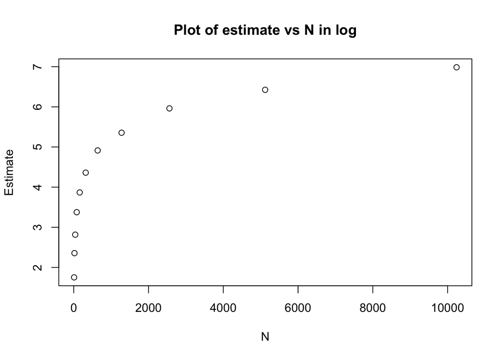

```r
graph_log <- plot(simData$N,log(simData$E),main="Plot of estimate vs N in log", xlab="N",ylab="Estimate")
```

We’ll now modify the simulation from 1.b to match the new requirements.

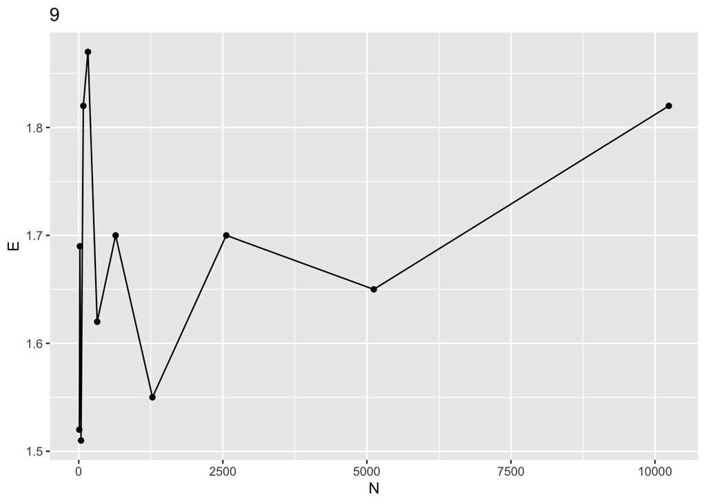

```r
#Creating the function for the simulation
intraTeamSim <- function(sizeA,sizeB){

  #Divide the teams of statisticians, sort each team
  Rgroup <- rexp(sizeA, 1)
  Rgroup <- sort(Rgroup)
  PYgroup <- rexp(sizeB, 1)
  PYgroup <- sort(PYgroup)

  #Draw simulations
  while(length(Rgroup)>0 & length(PYgroup)>0){
    #As mentioned, the turns are determined according to which group has the shortest time until shooting
    if (Rgroup[1]<PYgroup[1]) {
      #Rgroup shoots
      kill_R <- rdunif(1,1,length(Rgroup))
      Rgroup <- Rgroup[-kill_R]
      Rgroup[1] <- Rgroup[1] + rexp(1,1) #Add the reload time to the shooting time of the player who took the shot
      Rgroup <- sort(Rgroup) #Resort the group according to the shooting time of each player
    }
    else {

      #PYgroup shoots, then comments are the same as for Rgroup
      kill_PY <- rdunif(1,1,length(PYgroup))
      PYgroup <- PYgroup[-kill_PY]
      PYgroup[1] <- PYgroup[1] + rexp(1,1)
      PYgroup <- sort(PYgroup)
    }
  }

  #Finish and save the data from the simulation
  survived <- length(Rgroup) + length(PYgroup)
}

n <- c(10,20,40,80,160,320,640,1280,2560,5120,10240)

#Create a dataframe to save the results
simIntra <- data.frame(N=NA, E=NA)
for (i in n){
  survivors <- c()

  for (j in 1:100){
  survivors <- c(survivors,intraTeamSim(i,i))
  }

  e_x <- mean(survivors)

  simIntra <- rbind(simIntra, c(i, e_x))
}

graph <- ggplot(data=simIntra, aes(N, E)) + geom_point()+geom_line()+ ggtitle(sim)
graph
```

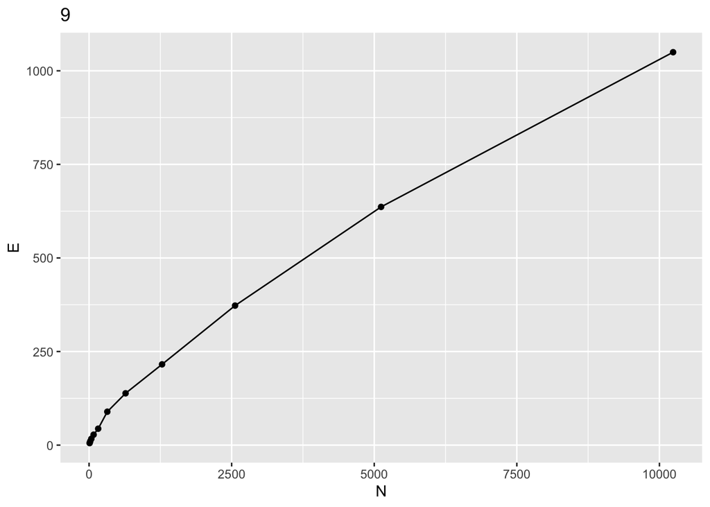

```r
#Creating the function for the simulation
drunkSim <- function(sizeA,sizeB){

  #Divide the teams of statisticians, sort each team
  Rgroup <- rexp(sizeA, 1)
  Rgroup <- sort(Rgroup)
  PYgroup <- rexp(sizeB, 1)
  PYgroup <- sort(PYgroup)

  #Draw simulations
  while(length(Rgroup)>0 & length(PYgroup)>0){
    #Randomize a group to kill
    killGroup <- rdunif(1,1,2)
    #As mentioned, the turns are determined according to which group has the shortest time until shooting
    if (Rgroup[1]<PYgroup[1]) {
      if(killGroup==1){
      #Rgroup shoots
      kill_R <- rdunif(1,1,length(Rgroup))
      Rgroup <- Rgroup[-kill_R]
      }
      else{
      kill_PY <- rdunif(1,1,length(PYgroup))
      PYgroup <- PYgroup[-kill_PY]
      }
      Rgroup[1] <- Rgroup[1] + rexp(1,1) #Add the reload time to the shooting time of the player who took the shot
      Rgroup <- sort(Rgroup) #Resort the group according to the shooting time of each player
    }
    else {

      #PYgroup shoots, then comments are the same as for Rgroup
      if(killGroup==1){
      kill_R <- rdunif(1,1,length(Rgroup))
      Rgroup <- Rgroup[-kill_R]
      }
      else{
      kill_PY <- rdunif(1,1,length(PYgroup))
      PYgroup <- PYgroup[-kill_PY]
      }
      PYgroup[1] <- PYgroup[1] + rexp(1,1)
      PYgroup <- sort(PYgroup)
    }
  }

  #Finish and save the data from the simulation
  survived <- length(Rgroup) + length(PYgroup)
}

n <- c(10,20,40,80,160,320,640,1280,2560,5120,10240)

#Create a dataframe to save the results
simIntra <- data.frame(N=NA, E=NA)
for (i in n){
  survivors <- c()

  for (j in 1:100){
  survivors <- c(survivors,simulation(i,i))
  }

  e_x <- mean(survivors)

  simIntra <- rbind(simIntra, c(i, e_x))
}

graph <- ggplot(data=simIntra, aes(N, E)) + geom_point()+geom_line()+ ggtitle(sim)
graph
```

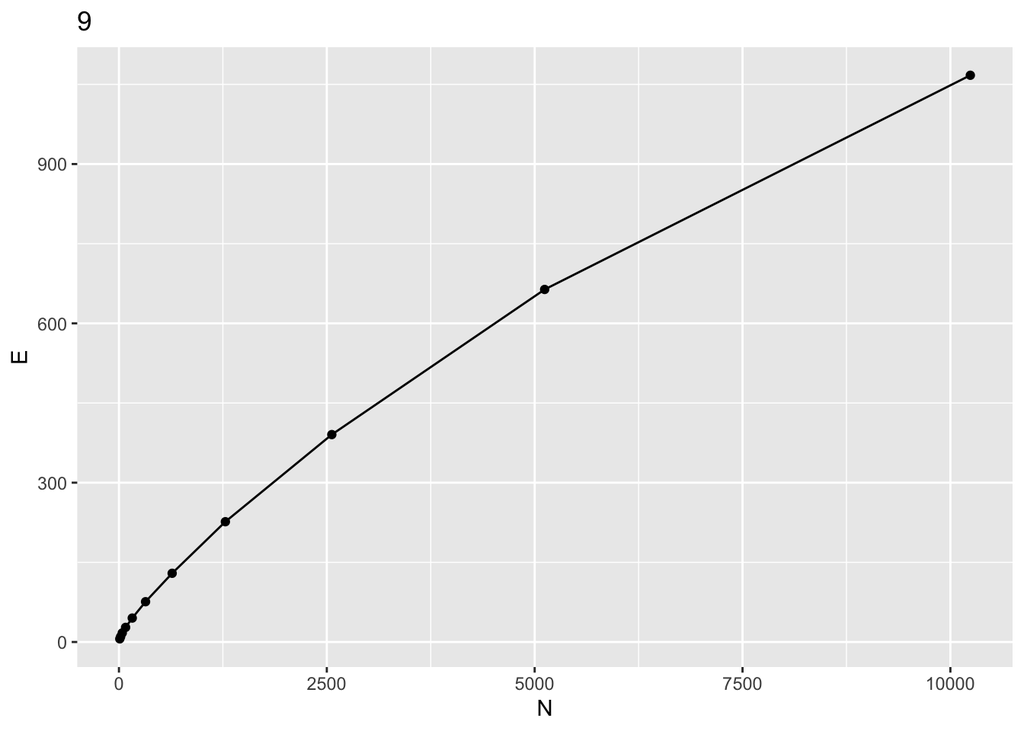

```r
#Creating the function for the simulation
zombieSim <- function(sizeA,sizeB){

  #Divide the teams of statisticians, sort each team, create groups of zombies
  Rgroup <- rexp(sizeA, 1)
  Rgroup <- sort(Rgroup)
  PYgroup <- rexp(sizeB, 1)
  PYgroup <- sort(PYgroup)
  Rzombie <- c()
  PYzombie <- c()
  #Draw simulations
  while(length(Rgroup)>0 & length(PYgroup)>0){
    #As mentioned, the turns are determined according to which group has the shortest time until shooting
    if(Rgroup[1]<PYgroup[1]){
      #Rgroup shoots
      kill_PY <- rdunif(1,1,length(Rgroup))
      PYgroup <- PYgroup[-kill_PY]
      Rgroup[1] <- Rgroup[1] + rexp(1,1) #Add the reload time to the shooting time of the player who took the shot
      Rgroup <- sort(Rgroup) #Resort the group according to the shooting time of each player
    }
      else{
      kill_R <- rdunif(1,1,length(Rgroup))
      Rgroup <- Rgroup[-kill_R]
      }
      #PYgroup shoots, then comments are the same as for Rgroup
      PYgroup[1] <- PYgroup[1] + rexp(1,1) #Add the reload time to the shooting time of the player who took the shot
      PYgroup <- sort(PYgroup) #Resort the group according to the shooting time of each player
      PYgroup[1] <- PYgroup[1] + rexp(1,1)
      PYgroup <- sort(PYgroup)
    }

  #Finish and save the data from the simulation
  survived <- length(Rgroup) + length(PYgroup)
}

n <- c(10,20,40,80,160,320,640,1280,2560,5120,10240)

#Create a dataframe to save the results
simIntra <- data.frame(N=NA, E=NA)
for (i in n){
  survivors <- c()

  for (j in 1:100){
  survivors <- c(survivors,simulation(i,i))
  }

  e_x <- mean(survivors)

  simIntra <- rbind(simIntra, c(i, e_x))
}

graph <- ggplot(data=simIntra, aes(N, E)) + geom_point()+geom_line()+ ggtitle(sim)
graph
```

## Q2. Analysis and Visualization of Twitter Data (60 pt)

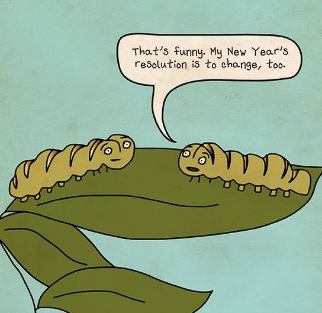

1. (4pt) Download and read the tweets dataset file `New-years-resolutions-DFE.csv` available [here](https://github.com/DataScienceHU/DataAnalysisR_2021/blob/master/New-years-resolutions-DFE.csv). The data represents new year’s resolutions tweets by American users wishing to change something in their life at the start of the year $2015$, downloaded from [here](https://data.world/crowdflower/2015-new-years-resolutions#).  
   Make sure that the tweets `text` column has `character` type. Show the top and bottom two rows of the resulting data-frame.
2. (5pt) The class `times` from the library `chron` stores and displays times in the above format `Hours:Minutes:Seconds`, but also treats them as numeric values between zero and one in units of days. For example, the time `10:48:00` corresponds to the value: $(10 + 48/60)/24 = 0.45$.  
   Create a new column with tweet times, of class `times`, with the time of the day for each tweet, in the above format. For example, the first entry in the column corresponding to the time of the first tweet should be: `10:48:00`.  
   Make a histogram showing the number of tweets in every hour of the $24$ hours in a day (that is, the bins are times between `00:00` and `00:59`, between `01:00` and `01:59` etc.).  
   At which hours do we see the most/fewest tweets?
3. (6pt) Plot the distribution of tweets `text` lengths (in characters) made by `females` and `males` separately. Who writes longer tweets?  
   Repeat, but this time plot the tweets lengths distribution for tweets in the four different regions of the US (`Midwest`, `Northeast`, `South` and `West`). Report the major differences in lengths between regions.  
   Finally, show the tweets lengths distribution for tweets for the $10$ different categories given in `Resolution_Category`. Report the major differences in lengths between categories.
4. (8pt) Compute the number of occurrences of each word in the `text` of all the tweets. Ignore upper/lower case differences.  
   Remove all common stop words (use the command `stop_words` from the tidytext package).  
   Remove words containing the special characters: `#`, `@`, `&`, `-`, `.`, `:` and `?`.  
   Remove also non-informative words: `resolution`, `rt`, `2015` and the empty word.  
   Plot the top $100$ remaining words in a word cloud, using the `wordcloud2` package.
5. (8pt) Find for each of the top (most frequent) $100$ words from 2.(d.) and each of the $10$ tweet categories, the fraction of tweets from this category where the word appears, and list them in a $100 \times 10$ table $F$, with $f_{ij}$ indicating the frequency of word $i$ in category $j$.  
   That is, if for example there were $200$ tweets in the category `Humor`, and $30$ of them contained the word `joke`, then the frequency was $0.15$.  
   Finally, for each of the $10$ categories we want to find the most `characteristic` words, i.e. words appearing more frequently in this category compared to other categories:  
   Formally, compute for each word $i$ and each category $j$ the difference between the frequency in the category and the maximum over frequencies in other categories: $d_{ij} = f_{ij} - \max_{k \neq j} f_{ik}$. (For example, if the word `joke` had frequency $0.15$ in `Humor`, and the next highest frequency for this word in other categories is $0.1$, then the difference for this word is $0.05$). Find for each category $j$ of the $10$ categories the $3$ `characteristic` words with the highest differences $d_{ij}$. Show a table with the $10$ categories and the $3$ `characteristic` words you have found for each of them. Do the words make sense for the categories?
6. (5pt) Plot the number of tweets in each of the $10$ categories shown in `Resolution_Category`.  
   Next, compute and show in a table of size $10 \times 4$ the number of tweets for each of the $10$ categories from users in each of the four regions of the USA: `Midwest`, `Northeast`, `South` and `West`.
7. (8pt) We want to test the null hypothesis that users in different `regions` have the same distribution over `categories` for their resolutions, using the Pearson chi-square statistic:
   $$S = \sum_{i=1}^{10} \sum_{j=1}^{4} \frac{(o_{ij}-e_{ij})^2}{e_{ij}}$$
   where $o_{ij}$ is the number of tweets on category $i$ from region $j$ computed in the table in the previous sub-question, assuming some indexing for the categories and regions (for example, $j=1,2,3,4$ for `Midwest`, `Northeast`, `South` and `West`, respectively, and similarly for the categories). The expected counts $e_{ij}$ are given by:
   $$e_{ij} = \frac{o_{ \bullet j} o_{i \bullet} } {o_{\bullet \bullet}}$$
   where $o_{i \bullet}$ is the sum over the $i$’th row (over all regions), $o_{\bullet j}$ the sum over the $j$’th column (over all categories) and $o_{\bullet \bullet}$ the sum over all observations in the table. These expected counts correspond to independence between the row (categories) and column (regions) according to the null hypothesis.
   Compute and report the test statistic for the table computed in 2.(f).
   Use the approximation $S \sim \chi^2(27)$ to compute a p-value for the above test (there are $(4-1) \times (10-1) = 27$ degrees of freedom). Would you reject the null hypothesis?
   Finally, repeat the analysis (computing a table, $\chi^2$-statistic and p-value) but this time split tweets by `gender` (`male` and `female`) instead of by `region`, to get a $10 \times 2$ table. Is there a significant difference in the distribution of categories between males and females?
8. (8pt) Use the following simulation to create a randomized dataset of `(category, region)` pairs for the tweets:
   For each tweet in the dataset keep the real `category` (from the column `Resolution_Category`) but change the `region` randomly by shuffling (permuting) the regions column in a random order, such that the total number of tweets from each region remains the same.
   Repeat this simulation $N=1,000$ times, each time creating a new shuffled random data, with the `category` column remaining the same and the `region` column shuffled each time in a random order. For each such simulation indexed $i$ compute the `category`-by-`region` occurance table and the resulting $\chi^2$ test statistic from 2.(g.) and call it $S_i$.
   Plot the empirical density distribution of the $S_i$ randomized test statistics and compare it to the theoretical density of the $\chi^2(27)$ distribution. Are the distributions similar?
   Finally, compute the empirical p-value, comparing the test statistic $S$ computed on the real data in 2.(g.) to the $1,000$ random statistics:
   $$\widehat{Pval} = \frac{1}{N} \sum_{i=1}^N 1_{\{S_i \geq S\}}.$$
   How different from the p-value obtained via the chi-square approximation?
9. (8pt) Compute for each of the $50$ states (and `DC` - District of Columbia) in the US the number of tweets made by users from this state.  
   Next, load the `usmap` library that contains the variable `statepop`.  
   Use this variable to compute the number of tweets per million residents for each state.  
   Remove `DC` and use the `usmap` package to make a map of USA states, where each state is colored by the number of tweets per million residents.  
   Report the three states with the maximal and minimal number.

**Solutions:**

```r
dataframe <- as.data.frame(read.csv("/Users/ohad/Documents/לימודים/Programming in R/lab 3/New-years-resolutions-DFE.csv",sep=","))
typeof(dataframe$text)
```

```
## [1] "character"
```

```r
head <- head(dataframe,2)
tail <- tail(dataframe,2)
```

```r
head
```

```
##                             other_topic
## 1 Read moore books, read less facebook.
## 2
##                                       resolution_topics gender         name
## 1                                         Eat healthier female  Dena_Marina
## 2 Humor about Personal Growth and Interests Resolutions female ninjagirl325
##   Resolution_Category retweet_count
## 1    Health & Fitness             0
## 2               Humor             1
##                                                                                                                                       text
## 1 #NewYearsResolution :: Read more books, No scrolling FB/checking email b4 breakfast, stay dedicated to PT/yoga to squash my achin' back!
## 2                                                                         #NewYearsResolution Finally master @ZJ10 's part of Kitchen Sink
##   tweet_coord  tweet_created tweet_date           tweet_id      tweet_location
## 1             12/31/14 10:48   12/31/14 550363000000000000 Southern California
## 2             12/31/14 10:47   12/31/14 550363000000000000          New Jersey
##   tweet_state              user_timezone tweet_region
## 1          CA Pacific Time (US & Canada)         West
## 2          NJ Central Time (US & Canada)    Northeast
```

```r
tail
```

```
##               other_topic resolution_topics gender         name
## 5010                         Join a startup female  itsmeJajael
## 5011 humor on resolutions   Improve my body female _LeahHarrell
##      Resolution_Category retweet_count
## 5010              Career            NA
## 5011    Health & Fitness            NA
##                                                                                                                                                        text
## 5010                                                              RT @kscmaghirang: To have an excellent job before or after graduation #NewYearsResolution
## 5011 RT @tompycan: #NewYearsResolution on Jan1: "I'm really going to get in shape this year!"\n\non Jan3: "I'm learning to love my body the way it\x89\xdb_
##      tweet_coord tweet_created tweet_date           tweet_id
## 5010             12/31/14 9:48   12/31/14 550348000000000000
## 5011             12/31/14 9:51   12/31/14 550348000000000000
##               tweet_location tweet_state              user_timezone
## 5010             Paris  USA           TX                    Beijing
## 5011 shenandoah conservatory          VA Eastern Time (US & Canada)
##      tweet_region
## 5010        South
## 5011        South
```

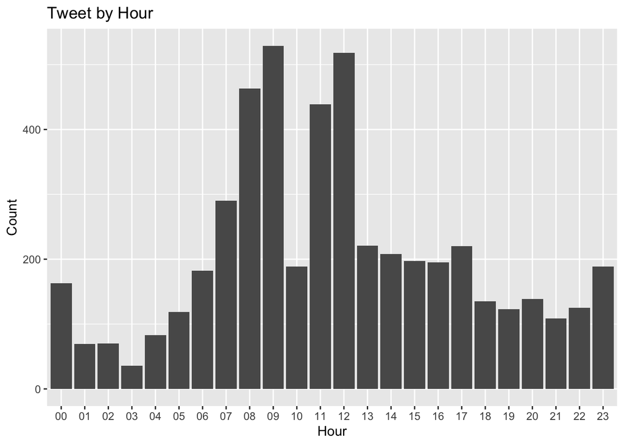

```r
#Getting the raw time using the POSIXct function
rtweetTime <- as.POSIXct(dataframe$tweet_created,format="%m/%d/%y %H:%M")
actualTime <- strftime(rtweetTime, format="%H:%M:00")

dataframe$raw <- rtweetTime
dataframe$actual <- actualTime
dataframe$hour <- strftime(rtweetTime, "%H")

ggplot(dataframe, aes(x=hour)) + geom_histogram(stat = "count") +ggtitle("Tweet by Hour")+xlab("Hour") +ylab("Count")
```

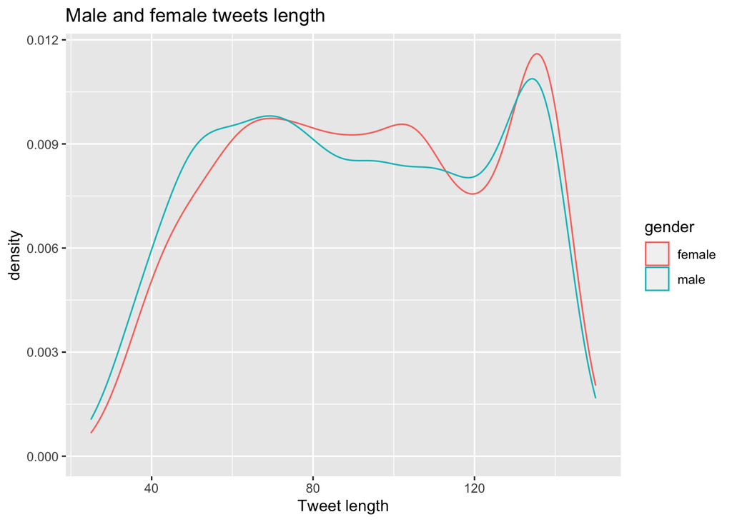

```r
ggplot(dataframe) +
    geom_density(aes(x = str_length(text),
    colour = gender)) +
    ggtitle("Male and female tweets length") +
    xlab("Tweet length")
```

As we can learn from the grapp 0-80 letters male tweet pretty often, 80+ female generally tend to tweet more. However, we may note that in the area of approximately 110-130 they are pretty equal. Overall it seems that female tend to tweet longer tweets.

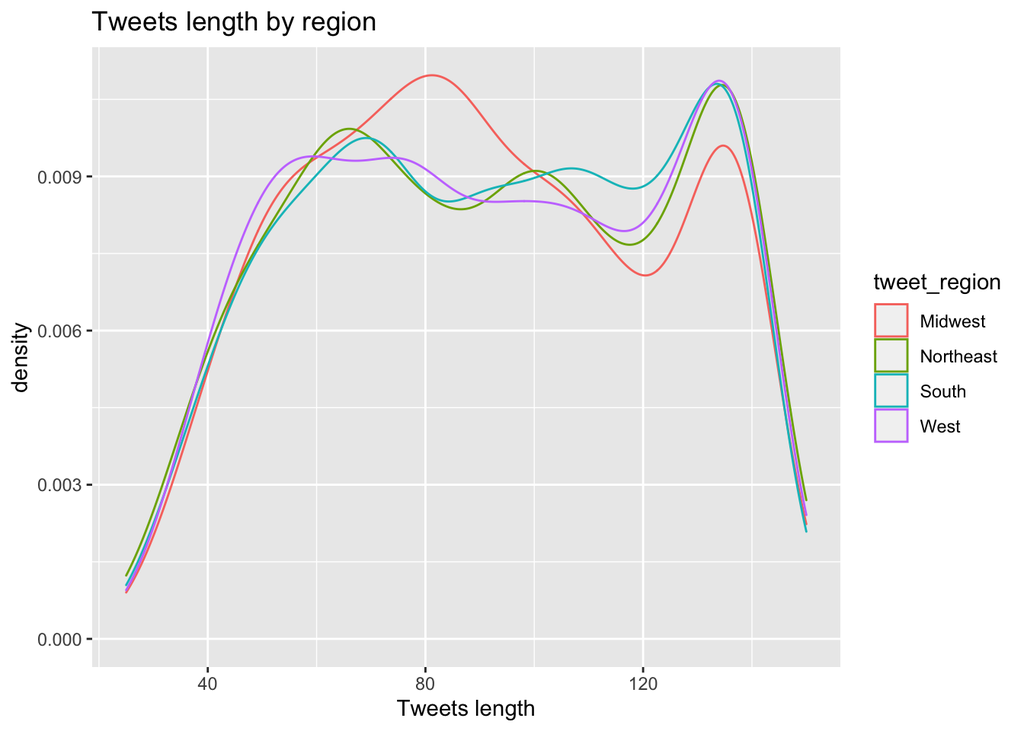

```r
ggplot(dataframe) + geom_density(aes(x = str_length(text),colour = tweet_region,line = tweet_region))+
  ggtitle("Tweets length by region")+xlab("Tweets length")
```

As we can see, 0-50 letters it’s pretty equal, around 8- letters midwest leads by far with the amount of tweets. Around 120 letters midwest is last, and then all the other regions are more dense until finally no one tweets any more than 135-140 letters in a tweet (could be the maximun on the app).

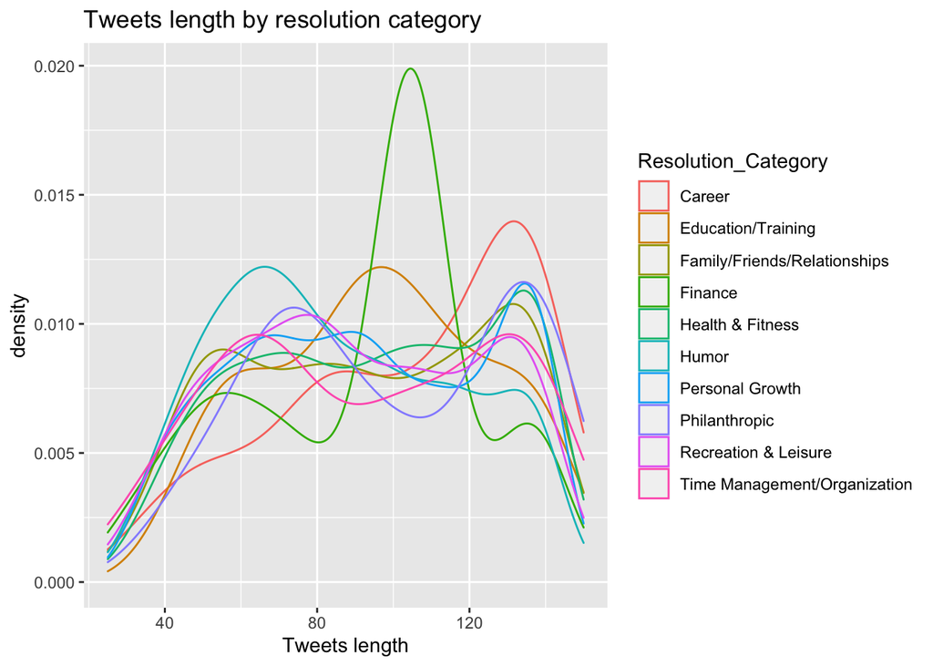

```r
ggplot(dataframe) + geom_density(aes(x = str_length(text),colour = Resolution_Category,line = Resolution_Category))+
  ggtitle("Tweets length by resolution category")+xlab("Tweets length")
```

### manage to lower over dataframe

```r
dataframe$text <- sapply(dataframe$text,function(row) iconv(row, "latin1", "ASCII", sub=""))
wCount <- sort(table(unlist(strsplit(tolower(dataframe$text), " "))), decreasing = TRUE)
wCount <- setNames(data.frame(wCount), c("word", "count"))  %>%  anti_join(stop_words, by = "word")


wCount$word <- str_replace_all(wCount$word,"2015", " ")
wCount$word <- str_replace_all(wCount$word,"resolution", " ")
wCount$word <- str_replace_all(wCount$word,"rt", " ")
wCount <- wCount[!str_detect(pattern =  "#|@|&|\\.|-|:|\\?|\\s|\\d|\\!", string=wCount$word),]
wCount <- wCount %>% arrange(desc(count)) %>% filter(!word=="")

Top100 <- wCount[1:100,]

# generate a wordclout for the top 100 words being tweeted
wordcloud2(data=Top100 , size = 1, shape = 'Hexagon', gridSize=10)
```

[interactive chart not shown]

```r
#generate the dataframe to compute the requency table
tableFreq <- data.frame(matrix(nrow = 100,ncol=10))
colnames(tableFreq) <- unique(dataframe$Resolution_Category)
rownames(tableFreq) <- c(Top100$word)
byCategories <- c(colnames(tableFreq))
usedWords <- c(rownames(tableFreq))

#calculate the data requested and fill it in
for(category in 1:length(byCategories)){
  freqData <- dataframe %>% filter(Resolution_Category==byCategories[category]) %>% select(text,Resolution_Category)
  for(word in 1:length(usedWords)){
    WordIndicator <- str_detect(freqData$text,as.character(usedWords[word]))
    counter <- sum(WordIndicator==TRUE)
    tableFreq[word,category] <- round(counter/length(freqData$text),3)
  }
}


tableFreq %>%
  kbl(caption = "Frequency table by word for each category")
```

Frequency table by word for each category

|  | Health & Fitness | Humor | Personal Growth | Philanthropic | Recreation & Leisure | Family/Friends/Relationships | Career | Finance | Education/Training | Time Management/Organization |
| --- | --- | --- | --- | --- | --- | --- | --- | --- | --- | --- |
| stop | 0.089 | 0.071 | 0.067 | 0.000 | 0.006 | 0.046 | 0.008 | 0.034 | 0.011 | 0.000 |
| _ | 0.170 | 0.153 | 0.183 | 0.262 | 0.139 | 0.217 | 0.087 | 0.148 | 0.202 | 0.069 |
| time | 0.042 | 0.032 | 0.051 | 0.036 | 0.032 | 0.094 | 0.040 | 0.011 | 0.045 | 0.126 |
| people | 0.007 | 0.037 | 0.052 | 0.083 | 0.004 | 0.131 | 0.032 | 0.000 | 0.011 | 0.023 |
| eat | 0.137 | 0.056 | 0.044 | 0.048 | 0.051 | 0.037 | 0.016 | 0.028 | 0.034 | 0.011 |
| __ | 0.070 | 0.055 | 0.054 | 0.036 | 0.041 | 0.066 | 0.032 | 0.062 | 0.067 | 0.011 |
| life | 0.023 | 0.013 | 0.066 | 0.060 | 0.024 | 0.034 | 0.056 | 0.006 | 0.011 | 0.057 |
| happy | 0.013 | 0.002 | 0.028 | 0.024 | 0.004 | 0.009 | 0.008 | 0.000 | 0.000 | 0.000 |
| love | 0.013 | 0.016 | 0.029 | 0.036 | 0.017 | 0.066 | 0.008 | 0.006 | 0.000 | 0.000 |
| day | 0.107 | 0.049 | 0.059 | 0.000 | 0.039 | 0.031 | 0.056 | 0.017 | 0.056 | 0.092 |
| learn | 0.008 | 0.009 | 0.016 | 0.024 | 0.011 | 0.006 | 0.000 | 0.011 | 0.236 | 0.011 |
| gonna | 0.019 | 0.020 | 0.011 | 0.024 | 0.009 | 0.011 | 0.000 | 0.017 | 0.011 | 0.000 |
| year’s | 0.002 | 0.001 | 0.004 | 0.000 | 0.004 | 0.003 | 0.000 | 0.000 | 0.000 | 0.000 |
| drink | 0.062 | 0.020 | 0.004 | 0.012 | 0.013 | 0.006 | 0.000 | 0.000 | 0.000 | 0.000 |
| gym | 0.080 | 0.012 | 0.001 | 0.000 | 0.000 | 0.000 | 0.000 | 0.006 | 0.000 | 0.000 |
| stay | 0.013 | 0.008 | 0.015 | 0.000 | 0.002 | 0.014 | 0.016 | 0.006 | 0.011 | 0.011 |
| continue | 0.005 | 0.013 | 0.015 | 0.012 | 0.006 | 0.009 | 0.008 | 0.011 | 0.045 | 0.000 |
| lose | 0.042 | 0.014 | 0.013 | 0.000 | 0.004 | 0.009 | 0.008 | 0.011 | 0.000 | 0.034 |
| fuck | 0.007 | 0.031 | 0.020 | 0.000 | 0.002 | 0.026 | 0.008 | 0.017 | 0.011 | 0.000 |
| smoking | 0.071 | 0.007 | 0.000 | 0.000 | 0.000 | 0.000 | 0.000 | 0.000 | 0.000 | 0.000 |
| read | 0.024 | 0.028 | 0.028 | 0.000 | 0.060 | 0.009 | 0.048 | 0.006 | 0.045 | 0.092 |
| resolve | 0.007 | 0.016 | 0.010 | 0.000 | 0.002 | 0.011 | 0.008 | 0.000 | 0.011 | 0.011 |
| friends | 0.008 | 0.006 | 0.010 | 0.000 | 0.006 | 0.145 | 0.000 | 0.000 | 0.000 | 0.000 |
| meet | 0.001 | 0.002 | 0.008 | 0.012 | 0.034 | 0.040 | 0.016 | 0.000 | 0.000 | 0.000 |
| money | 0.006 | 0.008 | 0.005 | 0.000 | 0.002 | 0.000 | 0.008 | 0.523 | 0.022 | 0.023 |
| spend | 0.005 | 0.003 | 0.009 | 0.000 | 0.004 | 0.028 | 0.000 | 0.085 | 0.000 | 0.023 |
| write | 0.001 | 0.013 | 0.011 | 0.000 | 0.006 | 0.003 | 0.032 | 0.000 | 0.011 | 0.000 |
| finally | 0.007 | 0.006 | 0.007 | 0.012 | 0.013 | 0.009 | 0.016 | 0.000 | 0.034 | 0.000 |
| ___ | 0.043 | 0.029 | 0.022 | 0.024 | 0.024 | 0.026 | 0.008 | 0.034 | 0.022 | 0.011 |
| watch | 0.006 | 0.009 | 0.004 | 0.012 | 0.058 | 0.003 | 0.000 | 0.000 | 0.011 | 0.000 |

[output cut: 70 more lines]

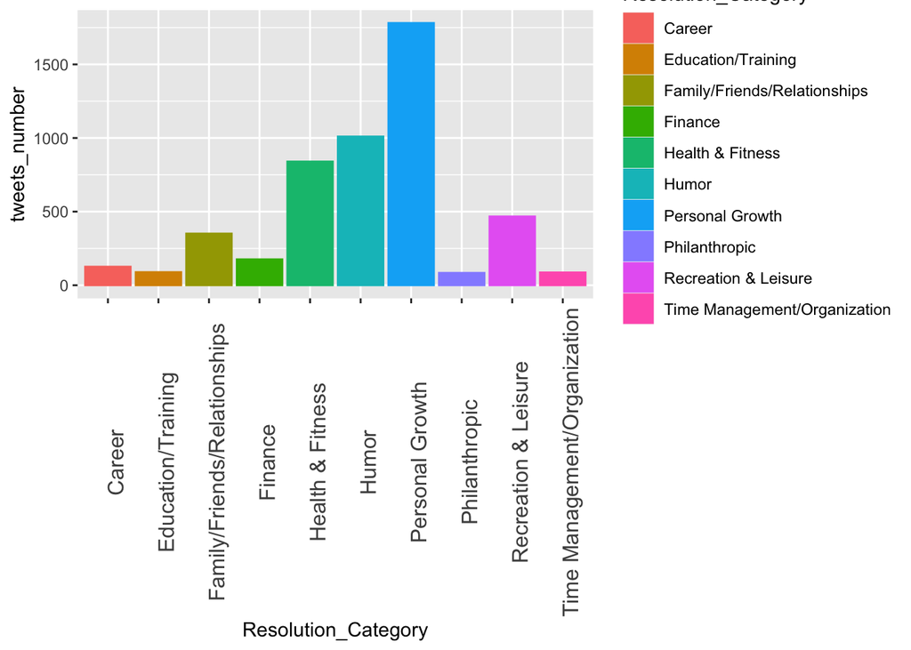

```r
plotTable <- data.frame(table(dataframe$Resolution_Category))
plotTable <- plotTable %>% rename(Resolution_Category=Var1,tweets_number=Freq)
ggplot(data = plotTable, aes(x = Resolution_Category, y = tweets_number, color = Resolution_Category, fill = Resolution_Category))+ geom_bar(stat = "identity")+ theme(axis.text.x = element_text(size = 12, angle = 90))
```

As can be seen from the plot personal growth is the leading category. On the other hand, philanthropic and time management and education/training are the least tweeted categories.

```r
#Divide into groups by region
regionWest <- dataframe %>% filter(tweet_region=="West")
regionWest <- as.data.frame(table(regionWest$Resolution_Category))
regionWest <- regionWest %>% rename(Category=Var1)

regioNortheast <- dataframe %>% filter(tweet_region=="Northeast")
regioNortheast <- as.data.frame(table(regioNortheast$Resolution_Category))
regioNortheast <- regioNortheast %>% rename(Category=Var1)


regionSouth <- dataframe %>% filter(tweet_region=="South")
regionSouth <- as.data.frame(table(regionSouth$Resolution_Category))
regionSouth <- regionSouth %>% rename(Category=Var1)


regionMidwest <- dataframe %>% filter(tweet_region=="Midwest")
regionMidwest <- as.data.frame(table(regionMidwest$Resolution_Category))
regionMidwest <- regionMidwest %>% rename(Category=Var1)


#Join all
continentalCategory <- regionWest
continentalCategory <- cbind(continentalCategory,regioNortheast$Freq,regionSouth$Freq,regionMidwest$Freq)
continentalCategory <- continentalCategory %>% rename(regionWest=Freq, regioNortheast=`regioNortheast$Freq`, regionSouth=`regionSouth$Freq`, regionMidwest=`regionMidwest$Freq`)

knitr::kable(continentalCategory,caption = "Amount of tweets in each category divided to regions")
```

Amount of tweets in each category divided to regions

| Category | regionWest | regioNortheast | regionSouth | regionMidwest |
| --- | --- | --- | --- | --- |
| Career | 28 | 30 | 44 | 24 |
| Education/Training | 23 | 19 | 33 | 14 |
| Family/Friends/Relationships | 103 | 79 | 97 | 72 |
| Finance | 41 | 32 | 65 | 38 |
| Health & Fitness | 195 | 170 | 284 | 191 |
| Humor | 283 | 226 | 300 | 201 |
| Personal Growth | 462 | 375 | 592 | 352 |
| Philanthropic | 19 | 19 | 34 | 12 |
| Recreation & Leisure | 124 | 101 | 146 | 96 |
| Time Management/Organization | 19 | 22 | 26 | 20 |

```r
byCategory <- continentalCategory %>% select(!Category)

tStatistic <- chisq.test(byCategory)
tStatistic
```

```
##
##  Pearson's Chi-squared test
##
## data:  byCategory
## X-squared = 26.366, df = 27, p-value = 0.4984
```

Hence we got that our test statistic is 26.366.

```r
round(tStatistic$p.value,3)
```

```
## [1] 0.498
```

We got that the Pvalue is 0.498.

Because the Pvalue received is bigger than alpha (which equals 0.05) we will not reject the null hypothesis.

```r
#Now we would like to compute the table by gender, and compare to our previous findings
tweetsbyMales <- dataframe %>% filter(gender=="male") %>% select(Resolution_Category)
tweetsbyMales <- table(dataframe %>% filter(gender=="male") %>% select(Resolution_Category))
tweetsbyFemales <- dataframe %>% filter(gender=="female") %>% select(Resolution_Category)
tweetsbyFemales <- table(dataframe %>% filter(gender=="female") %>% select(Resolution_Category))
tweetsbyFemales
```

```
##
##                       Career           Education/Training
##                           46                           44
## Family/Friends/Relationships                      Finance
##                          188                           96
##             Health & Fitness                        Humor
##                          467                          369
##              Personal Growth                Philanthropic
##                          975                           42
##         Recreation & Leisure Time Management/Organization
##                          216                           50
```

```r
tweetsbyGender <- cbind(tweetsbyMales,tweetsbyFemales)

#Calculate the t-statistic
tStat <- chisq.test(tweetsbyGender)
tStat
```

```
##
##  Pearson's Chi-squared test
##
## data:  tweetsbyGender
## X-squared = 116.67, df = 9, p-value < 0.00000000000000022
```

So we got that the t statistic is worth 116.672.

```r
pValue <- (1-pchisq(tStat$statistic,9))
round(pValue,3)
```

```
## X-squared
##         0
```

```r
nullAlpha <- 0.05
pValue < nullAlpha
```

```
## X-squared
##      TRUE
```

p-value < null hypothesis alpha –>> we reject the null hypothesis.

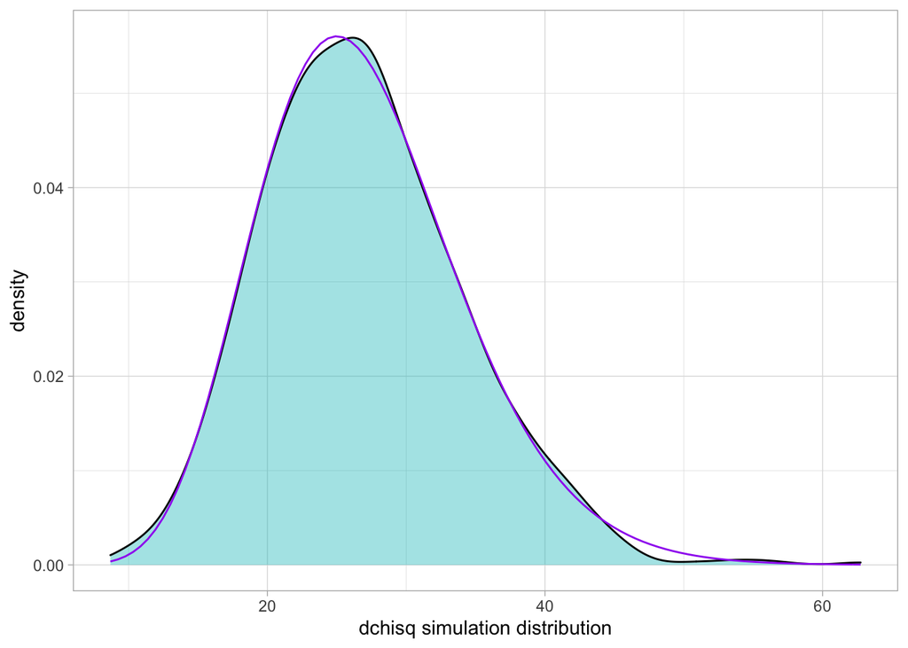

```r
permutateRegion <- function(){
  regions <- dataframe$tweet_region
  dataframe_ <- dataframe
  for (i in seq(length(rownames(dataframe)))) {
    random <- rdunif(1,1,length(regions))
    dataframe_[i,15] <- regions[random]
    regions <- regions[-random]
  }
  randomTable <- table(dataframe_$Resolution_Category,dataframe_$tweet_region)
  return(chisq.test(randomTable)$statistic)
}

regionSimulations <- c()
for(j in seq(1000)){
  regionSimulations[j] <- permutateRegion()
}

ggplot(data = as.data.frame(regionSimulations), aes(x=regionSimulations)) + geom_density(fill="#00Bfc4", alpha=0.4)+geom_text(y=0.6, x=55, label=" ", size = 4, color = "red") + theme_light() + stat_function(fun=dchisq, args = list(df=27), col='purple') +xlab("dchisq simulation distribution")
```

```r
tweetsbyState <- data.frame(table(dataframe$tweet_state))
colnames(tweetsbyState) <- c("State", "Tweets_Amount")

#Now we'll use the variable statepop from the library usmap, we'll use this variable in order to compute the amount of tweets per million people in each state
state_pop <- statepop %>% select(abbr,pop_2015)
state_pop <- state_pop %>% rename(State=abbr)
state_pop$State <- as.factor(state_pop$State)

state_pop <- left_join(state_pop,tweetsbyState, by="State")
state_pop <- state_pop %>% select(State,Tweets_Amount,pop_2015) %>% mutate(ratio_per_million=pop_2015/1000000)
tweetsbyState <- tweetsbyState %>% mutate(tweets_per_million=Tweets_Amount/state_pop$ratio_per_million) %>% filter(!State=="DC") %>% rename(state=State)

#We'll remove DC from the data as required
state_pop <- state_pop[state_pop$State != "DC", ]

state_pop <- state_pop %>% rename(state=State)

#Load USmap and plot
US_Map <- plot_usmap(data=state_pop, values = "ratio_per_million", color = "red", labels = TRUE, label_color = "orange") + theme(legend.position = "left")
US_Map
```

[output not shown]